V The V Lab

# Accelerated Failure Time and Cox Proportional Hazards Models

A Reproducible R Guide from Censoring and Survival Functions to Model Choice, Diagnosis, and Interpretation

School of Public Health Learning Module

Updated August 11, 2026

**Audience**Public health, medical, and statistics learners who have studied regression fundamentals

**Study time**Approximately 120–180 minutes

**Prerequisites**Confidence intervals, regression coefficients, and basic R syntax

About the tutorial data This tutorial uses the `survival` package and a fixed random seed to generate a simulated follow-up cohort. Every record, effect, and result is for teaching only, contains no identifiable personal health information, and must not be treated as clinical or causal evidence for a real population.

## How to use this tutorial

This module develops one question throughout: **Is an intervention associated with a later occurrence of the outcome?** We first study the structure of time-to-event outcomes, then answer the question on two distinct but complementary scales:

- the **Cox proportional hazards model (Cox PH)** addresses relative instantaneous event rates, with the hazard ratio (HR) as its principal effect measure;
- the **accelerated failure time model (AFT)** addresses how much event time is stretched or compressed, with the time ratio (TR) as its principal effect measure.

Read the concepts in sequence, run the code, interpret the output, and then open the knowledge checks. Code is shown by default and can be folded with the controls at the top of the page.

### Learning objectives

After completing this module, you should be able to:

- define the time origin, event, follow-up time, censoring, and risk set correctly;
- distinguish the survival, hazard, and cumulative hazard functions;
- fit and interpret HRs from Cox PH models and TRs from AFT models;
- explain the difference between the Cox partial likelihood and the full likelihood of a parametric AFT model;
- assess proportional hazards, functional form, influential observations, and AFT distributional assumptions;
- understand the special conversion between HRs and TRs under a Weibull model;
- choose a method according to the research question, the data-supported time range, and model assumptions;
- report absolute survival probabilities, relative effects, uncertainty, diagnostic findings, and limitations.

# 1 Survival Data: Events, Time, and Censoring

## 1.1 Why ordinary regression is not enough

An outcome in survival analysis includes not only **whether** an event occurs, but also **when** it occurs. When neither of two participants has an observed event, 2 months and 24 months of follow-up provide different amounts of information. An analysis restricted to participants with events would systematically discard the event-free time contributed by censored participants.

#### Time

From a prespecified origin to the event or last observation.

#### Event

Defined by reproducible rules with clinical or public health meaning.

#### Censoring

The event time is known only to exceed an observed time; this does not mean “no event.”

Common examples include time from diagnosis to death, treatment initiation to recurrence, discharge to readmission, or enrollment to discontinuation of a health behavior. “Survival” is a historical term; the event does not have to be death.

## 1.2 Define time zero, the time scale, and the event first

Every analysis should state at least the following:

| Component | Question that must be answered | Definition in this module |
| --- | --- | --- |
| Time zero | When does risk begin? | Date intervention or standard management begins |
| Time scale | Days, months, age, or calendar time? | Months since management began |
| Event | What counts as an event, and can it occur only once? | First occurrence of the simulated study endpoint |
| Competing event | Can another event prevent the outcome of interest? | Not simulated, for teaching simplicity |
| Observation endpoint | When does follow-up stop? | Event, loss to follow-up, or administrative cutoff |

Inconsistent definitions of time zero can introduce **immortal time bias**. For example, assigning only people who survive long enough to receive treatment to the treatment group while starting their follow-up at an earlier diagnosis date creates an artificial period during which death could not have occurred for that group.

## 1.3 Right censoring and its key assumption

If a participant has not experienced the event by the last observation, we know only that the true event time $T$ exceeds the censoring time $C$. We record:

$\tilde T=\min(T,C)$, together with $\delta=I(T\le C)$

Here, $\delta=1$ indicates an observed event and $\delta=0$ indicates right censoring. Other common observation structures include:

- **left censoring:** the event occurred before a known time, but its exact time is unknown;
- **interval censoring:** the event is known only to have occurred between two examinations;
- **left truncation/delayed entry:** an individual enters the risk set only after surviving and meeting entry conditions; this is not left censoring.

The standard Cox and `survreg()` examples here focus on right censoring. They generally require the censoring mechanism to carry no additional information about the potential event time after conditioning on model covariates. If participants whose condition is deteriorating rapidly are more likely to be lost to follow-up, and that deterioration is not adequately recorded in the model, treating loss to follow-up as independent censoring can introduce bias.

## 1.4 Survival, hazard, and cumulative hazard functions

Let $T$ be a continuous event time:

Survival function: $S(t)=P(T>t)$

Hazard function: $h(t)=\lim_{\Delta t\to 0}\dfrac{P(t\le T<t+\Delta t\mid T\ge t)}{\Delta t}$

Cumulative hazard: $H(t)=\int_0^t h(u)\,du=-\log S(t)$

The hazard function is the instantaneous event rate immediately after a time among individuals who remain at risk. It is not a probability over a fixed interval and need not lie between 0 and 1. The survival probability $S(t)$ is the probability of remaining event-free from time zero through time $t$.

Hazard is not risk An HR compares conditional instantaneous event rates; a risk ratio compares cumulative event probabilities by a specified time. Their numerical values usually differ even when the HR is constant over time.

## 1.5 Constructing a survival outcome in R

`Surv(time, event)` stores right-censoring information using a follow-up-time column and an event-indicator column. This module explicitly uses `1 = event` and `0 = censored` rather than relying on automatic interpretation of character or factor states.

```r
stopifnot(
  all(survival_data$time_months > 0),
  all(survival_data$event %in% c(0, 1)),
  !anyNA(survival_data)
)

survival_outcome <- with(
  survival_data,
  survival::Surv(time_months, event)
)

data_preview <- transform(
  head(survival_data[, c(
    "participant_id", "time_months", "event",
    "treatment", "age", "severity", "biomarker"
  )]),
  event = ifelse(event == 1, "Event", "Censored"),
  treatment = ifelse(treatment == "Intervention", "Intervention", "Standard management"),
  severity = c("Mild" = "Mild", "Moderate" = "Moderate", "Severe" = "Severe")[
    as.character(severity)
  ]
)

knitr::kable(
  data_preview,
  col.names = c(
    "Participant", "Observed time (months)", "Observed endpoint",
    "Management strategy", "Age", "Baseline severity", "Standardized biomarker"
  ),
  caption = "First six rows of the simulated follow-up data"
)
```

First six rows of the simulated follow-up data

| Participant | Observed time (months) | Observed endpoint | Management strategy | Age | Baseline severity | Standardized biomarker |
| --- | --- | --- | --- | --- | --- | --- |
| S001 | 2.17 | Event | Standard management | 72 | Mild | -1.54 |
| S002 | 3.05 | Event | Intervention | 47 | Severe | 0.61 |
| S003 | 11.72 | Censored | Standard management | 52 | Mild | 0.26 |
| S004 | 28.41 | Censored | Intervention | 37 | Mild | 0.51 |
| S005 | 13.97 | Event | Standard management | 43 | Mild | -0.55 |
| S006 | 3.18 | Event | Standard management | 64 | Mild | -0.70 |

```r
followup_summary <- data.frame(
  Sample_size = nrow(survival_data),
  Events = sum(survival_data$event),
  Censored = sum(survival_data$event == 0),
  Censoring_percentage = pct(mean(survival_data$event == 0)),
  Median_observed_months = median(survival_data$time_months)
)
knitr::kable(
  followup_summary,
  digits = 2,
  col.names = c(
    "Sample size", "Events", "Censored",
    "Censoring percentage", "Median observed time (months)"
  ),
  caption = "Overview of follow-up completeness"
)
```

Overview of follow-up completeness

| Sample size | Events | Censored | Censoring percentage | Median observed time (months) |
| --- | --- | --- | --- | --- |
| 650 | 416 | 234 | 36.0% | 11.1 |

Longer observed time does not necessarily imply longer true event time because censored event times are unknown. A data description should report the sample size, event count, censoring count, time range, and number at risk in key groups.

## 1.6 Kaplan–Meier curves: inspect the data before modeling

The Kaplan–Meier (KM) estimator updates survival probability at each event time using the risk set:

$\widehat S(t)=\prod_{t_j\le t}\left(1-\dfrac{d_j}{n_j}\right)$

Here, $d_j$ is the number of events at time $t_j$, and $n_j$ is the number still at risk immediately before that time. Censoring is not counted as an event, but a participant leaves subsequent risk sets after being censored.

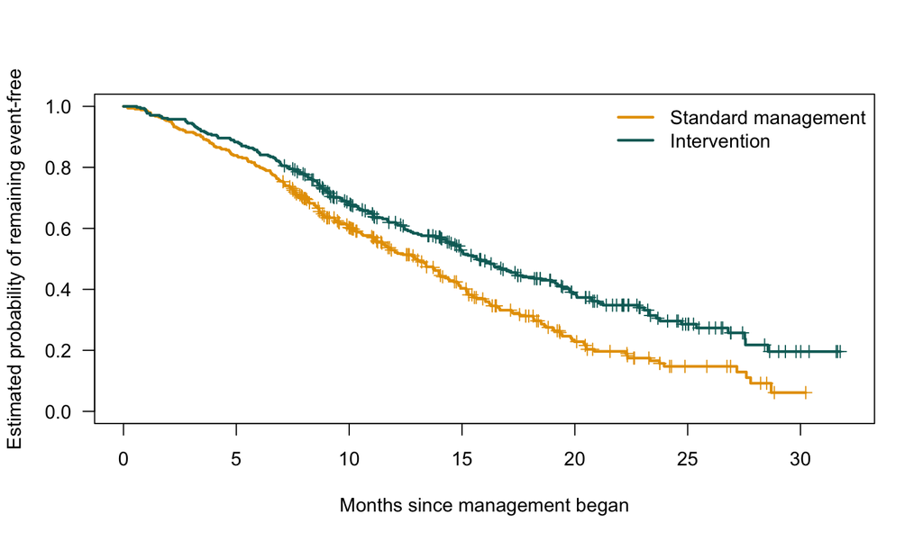

Kaplan–Meier survival curves by management strategy. Short vertical marks indicate censoring; fewer participants remain at risk late in follow-up, so uncertainty is usually greater.

```r
km_fit <- survival::survfit(
  survival_outcome ~ treatment,
  data = survival_data,
  conf.type = "log-log"
)

plot(
  km_fit,
  col = c(palette_surv["orange"], palette_surv["teal"]),
  lwd = 2.3,
  mark.time = TRUE,
  conf.int = FALSE,
  xlab = "Months since management began",
  ylab = "Estimated probability of remaining event-free",
  xlim = c(0, 32),
  ylim = c(0, 1),
  las = 1
)
legend(
  "topright",
  legend = c("Standard management", "Intervention"),
  col = c(palette_surv["orange"], palette_surv["teal"]),
  lwd = 2.3,
  bty = "n"
)
```

```r
km_selected <- summary(
  km_fit,
  times = c(6, 12, 18)
)

km_table <- data.frame(
  Management = ifelse(
    km_selected$strata == "treatment=Intervention",
    "Intervention",
    "Standard management"
  ),
  Time_months = km_selected$time,
  Survival_probability = km_selected$surv,
  CI_lower = km_selected$lower,
  CI_upper = km_selected$upper
)

knitr::kable(
  km_table,
  digits = 3,
  col.names = c(
    "Management strategy", "Time (months)", "Survival probability",
    "95% CI lower", "95% CI upper"
  ),
  caption = "KM survival probabilities and 95% confidence intervals at prespecified times"
)
```

KM survival probabilities and 95% confidence intervals at prespecified times

| Management strategy | Time (months) | Survival probability | 95% CI lower | 95% CI upper |
| --- | --- | --- | --- | --- |
| Standard management | 6 | 0.804 | 0.758 | 0.842 |
| Standard management | 12 | 0.529 | 0.472 | 0.582 |
| Standard management | 18 | 0.312 | 0.257 | 0.370 |
| Intervention | 6 | 0.847 | 0.802 | 0.883 |
| Intervention | 12 | 0.619 | 0.561 | 0.672 |
| Intervention | 18 | 0.440 | 0.378 | 0.500 |

```r
km_risk_summary <- summary(
  km_fit,
  times = c(0, 6, 12, 18, 24)
)
km_risk_long <- data.frame(
  Management = ifelse(
    km_risk_summary$strata == "treatment=Intervention",
    "Intervention",
    "Standard management"
  ),
  Time_months = km_risk_summary$time,
  Number_at_risk = km_risk_summary$n.risk
)
km_risk_table <- xtabs(
  Number_at_risk ~ Management + Time_months,
  data = km_risk_long
)
names(dimnames(km_risk_table)) <- c("Management strategy", "Time (months)")

knitr::kable(
  km_risk_table,
  caption = "Numbers remaining at risk immediately before selected KM time points"
)
```

Numbers remaining at risk immediately before selected KM time points

|  | 0 | 6 | 12 | 18 | 24 |
| --- | --- | --- | --- | --- | --- |
| Intervention | 308 | 261 | 159 | 87 | 32 |
| Standard management | 342 | 275 | 139 | 61 | 15 |

KM curves are unadjusted descriptions. Differences between curves may reflect management strategy, age, severity, or other baseline differences. Crossing curves, systematic changes in separation over time, or sparse late follow-up can all affect subsequent model choice and interpretation.

KM estimation also relies on censoring carrying no additional prognostic information within groups. If a group’s curve never falls to 0.50, its KM median event time is **not reached**; the last observed time must not be reported as the median.

**Check your understanding: does a censored participant have “no event”?**

A participant is lost to follow-up after 10 months without a prior outcome. Can the event time be recorded as infinity or the outcome as never occurring?

**Answer:** No. We know only that the true event time exceeds 10 months. Right-censoring methods retain the information from those 10 months without assuming that the event can never occur later.

# 2 The Cox Proportional Hazards Model

## 2.1 What question does the model answer?

The Cox PH model links covariates to the conditional hazard function:

$h(t\mid X)=h_0(t)\exp(\beta_1X_1+\cdots+\beta_pX_p)$

- $h_0(t)$ is the unknown baseline hazard function and may vary freely over time;
- $\exp(\beta_j)$ is the HR associated with a one-unit increase in $X_j$, holding other covariates fixed;
- “proportional hazards” means that the ratio of two hazard functions does not change over time.

For a binary intervention variable:

$HR=\dfrac{h(t\mid \text{intervention})}{h(t\mid \text{standard management})}=\exp(\beta_{\text{intervention}})$

An HR below 1 indicates a lower instantaneous event rate in the intervention group among comparable participants who remain at risk at each time. It does not directly quantify the reduction in event probability and is not a multiplier for survival time.

## 2.2 How partial likelihood avoids specifying the baseline hazard

At every observed event time, the Cox model compares the covariates of the participant who has the event with those of everyone in the risk set at that time. Partial likelihood estimates $\beta$ primarily from relative information about who experiences the event next, without first imposing a parametric distribution on $h_0(t)$.

Ignoring tied events for the moment, the partial likelihood is:

$$L_p(\beta)=
\prod_{i:\delta_i=1}
\frac{\exp(X_i^\mathsf{T}\beta)}
{\sum_{j\in R(t_i)}\exp(X_j^\mathsf{T}\beta)},$$

Here, $R(t_i)$ is the set of participants still at risk immediately before event time $t_i$. The numerator corresponds to the participant who actually has the event, and the denominator sums the relative hazards of everyone who could have had it at that time.

Two consequences follow:

1. the Cox model is flexible about the shape of the baseline hazard;
2. its coefficients are estimated by partial likelihood, whereas a parametric AFT model’s AIC is based on a full event-time likelihood, so the two AIC values should not be compared directly to decide which model is better.

When multiple events are recorded at the same time, **tied events** occur. Times in this module are rounded to two decimal places, so we explicitly use the commonly applied Efron approximation. If time is inherently recorded in coarse discrete intervals and ties are very frequent, reconsider both the time representation and a discrete-time model.

## 2.3 Fitting an adjusted Cox model

Age is divided by 10 and centered at 55 years so that its HR compares a 10-year increase and the reference age used for prediction is easy to interpret.

```r
cox_fit <- survival::coxph(
  survival::Surv(time_months, event) ~
    treatment + age10 + severity + biomarker,
  data = survival_data,
  ties = "efron",
  x = TRUE,
  y = TRUE
)

cox_summary <- summary(cox_fit)
cox_terms <- rownames(cox_summary$coefficients)
cox_labels <- c(
  treatmentIntervention = "Intervention vs standard management",
  age10 = "Age (per 10-year increase)",
  severityModerate = "Moderate vs mild severity",
  severitySevere = "Severe vs mild severity",
  biomarker = "Biomarker (per 1-SD increase)"
)

cox_results <- data.frame(
  Term = unname(cox_labels[cox_terms]),
  HR = cox_summary$coefficients[, "exp(coef)"],
  `95% CI lower` = cox_summary$conf.int[, "lower .95"],
  `95% CI upper` = cox_summary$conf.int[, "upper .95"],
  `p-value` = format_p(cox_summary$coefficients[, "Pr(>|z|)"]),
  check.names = FALSE
)

knitr::kable(
  cox_results,
  digits = 3,
  align = c("l", "r", "r", "r", "r"),
  caption = "Adjusted Cox proportional hazards model"
)
```

Adjusted Cox proportional hazards model

|  | Term | HR | 95% CI lower | 95% CI upper | p-value |
| --- | --- | --- | --- | --- | --- |
| treatmentIntervention | Intervention vs standard management | 0.669 | 0.549 | 0.815 | <0.001 |
| age10 | Age (per 10-year increase) | 1.194 | 1.096 | 1.301 | <0.001 |
| severityModerate | Moderate vs mild severity | 1.467 | 1.182 | 1.821 | <0.001 |
| severitySevere | Severe vs mild severity | 2.334 | 1.791 | 3.043 | <0.001 |
| biomarker | Biomarker (per 1-SD increase) | 0.998 | 0.901 | 1.104 | 0.962 |

```r
cox_treatment_hr <- unname(
  cox_summary$coefficients["treatmentIntervention", "exp(coef)"]
)
cox_treatment_ci <- unname(
  cox_summary$conf.int[
    "treatmentIntervention",
    c("lower .95", "upper .95")
  ]
)
```

Holding age, baseline severity, and biomarker level fixed, the estimated HR for intervention versus standard management is 0.67 (95% confidence interval: 0.55 to 0.82). If proportional hazards and the other model assumptions hold, participants in the intervention group who remain at risk have an instantaneous event rate approximately 66.9% of that in the standard-management group. This is not direct evidence that event risk is reduced by 33.1%, nor is it a causal effect.

### 2.3.1 Adjusted survival curves

The HR is a relative measure. To support decisions, report absolute survival probabilities at clinically or publicly meaningful times as well. The following example fixes a reference individual at age 55, mild baseline severity, and a biomarker value of 0.

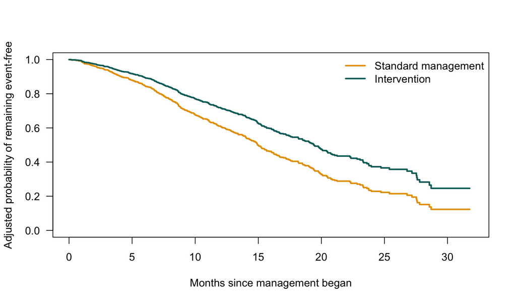

Adjusted survival curves from the Cox model for the same reference covariate profile. The absolute level of each curve depends on the estimated baseline survival function.

```r
reference_profiles <- data.frame(
  treatment = factor(
    c("Standard", "Intervention"),
    levels = levels(survival_data$treatment)
  ),
  age10 = c(0, 0),
  severity = factor(
    c("Mild", "Mild"),
    levels = levels(survival_data$severity)
  ),
  biomarker = c(0, 0)
)

cox_reference_curves <- survival::survfit(
  cox_fit,
  newdata = reference_profiles
)

plot(
  cox_reference_curves,
  col = c(palette_surv["orange"], palette_surv["teal"]),
  lwd = 2.3,
  conf.int = FALSE,
  xlab = "Months since management began",
  ylab = "Adjusted probability of remaining event-free",
  xlim = c(0, 32),
  ylim = c(0, 1),
  las = 1
)
legend(
  "topright",
  legend = c("Standard management", "Intervention"),
  col = c(palette_surv["orange"], palette_surv["teal"]),
  lwd = 2.3,
  bty = "n"
)
```

These are **conditional predictions** and represent only the covariate profiles supplied in `newdata`. If the target is population-average survival, prespecify a standard population and average predictions across its members. Do not automatically describe a “typical individual” curve as a population curve.

## 2.4 What assumptions does the Cox model require?

| Assumption | Meaning | Common assessment |
| --- | --- | --- |
| Proportional hazards | The HR for each covariate remains constant over time | Schoenfeld residual plots, `cox.zph()`, stratified curves, and subject-matter knowledge |
| Functional form of continuous variables | The form in the linear predictor is correct; for example, age is approximately linear on the log-hazard scale | Martingale residuals, splines, and prespecified nonlinear terms |
| Conditional independent censoring | After conditioning on covariates, censoring no longer predicts event time | Compare loss-to-follow-up patterns, perform sensitivity analyses, and improve data collection |
| Dependence structure is handled | Clustering, recurrent events, or multicenter correlation cannot be treated as independent | Robust variance, frailty, multilevel, or recurrent-event methods |
| Covariate measurement and temporal order are appropriate | Post-baseline information must not be substituted incorrectly for baseline values | Protocol, data-dictionary, and timestamp review |

### 2.4.1 Assessing proportional hazards with Schoenfeld residuals

`cox.zph()` assesses whether scaled Schoenfeld residuals show a systematic trend over time. A small p-value suggests that an effect may vary with time; a large p-value means only that the current data provide no strong evidence against PH, not that exact proportionality has been proven.

```r
cox_ph_test <- survival::cox.zph(cox_fit, transform = "km")

cox_ph_table <- data.frame(
  Test = c(
    "Management strategy", "Age", "Baseline severity",
    "Biomarker", "Global test"
  ),
  Chi_square = cox_ph_test$table[, "chisq"],
  df = cox_ph_test$table[, "df"],
  `p-value` = format_p(cox_ph_test$table[, "p"]),
  check.names = FALSE
)

knitr::kable(
  cox_ph_table,
  digits = 3,
  col.names = c("Test", "Chi-square statistic", "Degrees of freedom", "p-value"),
  caption = "Proportional hazards tests based on scaled Schoenfeld residuals"
)
```

Proportional hazards tests based on scaled Schoenfeld residuals

|  | Test | Chi-square statistic | Degrees of freedom | p-value |
| --- | --- | --- | --- | --- |
| treatment | Management strategy | 1.170 | 1 | 0.279 |
| age10 | Age | 0.230 | 1 | 0.631 |
| severity | Baseline severity | 0.072 | 2 | 0.965 |
| biomarker | Biomarker | 1.305 | 1 | 0.253 |
| GLOBAL | Global test | 2.922 | 5 | 0.712 |

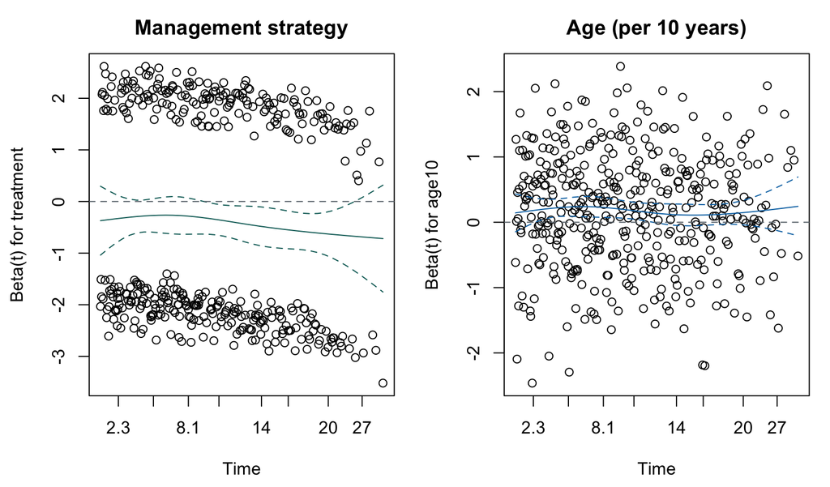

Scaled Schoenfeld residual diagnostics for management strategy and age. A smooth curve that clearly departs from a horizontal line suggests that the corresponding log HR may change over time.

```r
old_par <- par(mfrow = c(1, 2), mar = c(4.4, 4.3, 2.6, 1))

plot(
  cox_ph_test,
  var = 1,
  resid = TRUE,
  se = TRUE,
  col = palette_surv["teal"]
)
abline(h = 0, lty = 2, col = palette_surv["gray"])
title("Management strategy")

plot(
  cox_ph_test,
  var = 2,
  resid = TRUE,
  se = TRUE,
  col = palette_surv["blue"]
)
abline(h = 0, lty = 2, col = palette_surv["gray"])
title("Age (per 10 years)")
```

```r
par(old_par)
```

The global test p-value in these simulated data is 0.712. Together with the plots, there is no clear evidence against PH, but this conclusion remains limited by the event count, follow-up range, and statistical power. In particular, a model should not be selected mechanically from multiple covariate-specific p-values.

### 2.4.2 Assessing the functional form of a continuous variable

If the true age effect is curved, forcing a linear age term can distort both the HR and covariate adjustment. One exploratory approach is to fit a model without age and then plot Martingale residuals against age; a smooth curve suggests a potentially useful functional form. A formal analysis should prespecify flexible forms such as restricted cubic splines using subject-matter knowledge and avoid repeated data-driven searching.

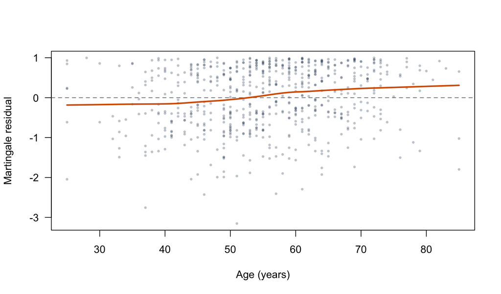

Age plotted against Martingale residuals from a Cox model that omits age. The smooth line explores a possible functional form for age and is not a formal significance test.

```r
cox_without_age <- survival::coxph(
  survival::Surv(time_months, event) ~
    treatment + severity + biomarker,
  data = survival_data,
  ties = "efron"
)

martingale_age <- residuals(cox_without_age, type = "martingale")

plot(
  survival_data$age,
  martingale_age,
  pch = 16,
  cex = 0.55,
  col = grDevices::adjustcolor(palette_surv["navy"], alpha.f = 0.28),
  xlab = "Age (years)",
  ylab = "Martingale residual",
  las = 1
)
abline(h = 0, lty = 2, col = palette_surv["gray"])
lines(
  lowess(survival_data$age, martingale_age, f = 0.65),
  col = palette_surv["vermillion"],
  lwd = 2.4
)
```

### 2.4.3 Assessing unusual and influential observations

Deviance residuals can help identify observations whose event patterns are fitted poorly, while dfbeta residuals approximate how deleting one observation would affect each coefficient. They are starting points for investigation, not rules for automatic deletion.

```r
cox_dfbeta <- residuals(cox_fit, type = "dfbeta")
colnames(cox_dfbeta) <- names(coef(cox_fit))
max_dfbeta <- apply(abs(cox_dfbeta), 2, max)

influence_table <- data.frame(
  Coefficient = unname(cox_labels[colnames(cox_dfbeta)]),
  Maximum_absolute_dfbeta = max_dfbeta,
  check.names = FALSE
)

knitr::kable(
  influence_table,
  digits = 3,
  col.names = c("Coefficient", "Maximum absolute dfbeta"),
  caption = "Largest absolute dfbeta residual observed for each coefficient"
)
```

Largest absolute dfbeta residual observed for each coefficient

|  | Coefficient | Maximum absolute dfbeta |
| --- | --- | --- |
| treatmentIntervention | Intervention vs standard management | 0.015 |
| age10 | Age (per 10-year increase) | 0.016 |
| severityModerate | Moderate vs mild severity | 0.018 |
| severitySevere | Severe vs mild severity | 0.039 |
| biomarker | Biomarker (per 1-SD increase) | 0.009 |

After finding an influential observation, verify its time, event code, covariates, and eligibility, and report sensitivity analyses with and without it when appropriate. Deleting an observation merely because it does not conform to the model creates a new source of bias.

## 2.5 What to do when proportional hazards does not hold

The response should follow the scientific question, not just a diagnostic p-value:

- if a covariate is included only for adjustment and its HR is not needed, use `strata()` to allow different baseline hazards across its levels;
- if the effect of the primary exposure varies over time, explicitly include an exposure-by-time interaction and report $HR(t)$;
- if risk at a fixed time or average event-free time is more important, report adjusted survival probabilities or restricted mean survival time (RMST);
- if nonproportional hazards reflect a different time-scale mechanism, consider a suitable AFT model, flexible parametric model, or piecewise model;
- if apparent change occurs only at a few late times with very small risk sets, first assess whether the estimates are sufficiently stable.

The code below demonstrates syntax only. The function inside `tt()` must be designed in advance for the scientific problem; $\log(t+1)$ is not a universal solution.

```r
cox_time_varying <- survival::coxph(
  survival::Surv(time_months, event) ~
    treatment_num + age10 + severity + biomarker +
    tt(treatment_num),
  data = survival_data,
  ties = "efron",
  tt = function(x, t, ...) x * log(t + 1)
)
```

A time-varying effect is different from a time-varying covariate “The intervention HR changes over time” describes a time-varying effect. “Blood pressure is repeatedly updated during follow-up” describes a time-varying covariate. The latter generally requires multiple rows per participant in start–stop format with `Surv(start, stop, event)`, and every measurement must be ordered correctly in time.

**Check your understanding: how should HR = 0.70 be described?**

Can we say, “The intervention reduces 12-month event risk by 30%”?

**Answer:** Not directly. An HR of 0.70 means that, among participants who remain at risk and have the same model covariates, the intervention group has approximately 0.70 times the instantaneous event rate if PH holds. A 12-month risk difference or risk ratio must be calculated separately from the corresponding survival probabilities.

# 3 The Accelerated Failure Time Model

## 3.1 Shifting from event rates to event times

An AFT model directly describes log event time:

$\log(T)=\beta_0+\beta_1X_1+\cdots+\beta_pX_p+\sigma\varepsilon$

An equivalent time-scaling expression is:

$S(t\mid X)=S_0\{t\exp(-X^\mathsf{T}\beta)\}$

For a one-unit increase in $X_j$:

$TR=\exp(\beta_j)$

In the standard AFT structure, the TR is a common multiplier for every conditional event-time quantile:

- $TR>1$: the time scale is stretched, so events tend to occur later;
- $TR<1$: the time scale is compressed, so events tend to occur earlier;
- $TR=1$: the modeled event-time scale is unchanged.

For example, TR = 1.30 means that, holding other covariates fixed, the time required to reach the same event-time quantile is multiplied by 1.30. If the conditional median event time under standard management is 10 months, the corresponding conditional median under intervention is 13 months. This does not mean that risk is reduced by 30%.

A parametric AFT model constructs a full likelihood from the event density for observed events and the information that censored participants remained event-free through their observation times:

$$L(\theta)=
\prod_i
f(\tilde T_i\mid X_i;\theta)^{\delta_i}
S(\tilde T_i\mid X_i;\theta)^{1-\delta_i}.$$

Thus, an event record contributes the density $f$, while a right-censored record contributes the survival probability $S$. The chosen distribution determines both contributions as well as tail behavior.

## 3.2 A parametric AFT model requires an event-time distribution

The parametric AFT models in this tutorial use a complete event-time distribution. `survreg()` specifies an error distribution for $\log(T)$ in location–scale form. Semiparametric AFT methods based on rank estimation also exist and do not require the same full parametric distribution. Common `survreg()` choices include:

| `survreg()` distribution | Distribution of $T$ | Typical hazard shape | Also satisfies PH? |
| --- | --- | --- | --- |
| `exponential` | Exponential | Constant hazard | Yes |
| `weibull` | Weibull | Monotonically increasing or decreasing | Yes |
| `lognormal` | Log-normal | Often increases and then decreases | Usually no |
| `loglogistic` | Log-logistic | Can increase and then decrease; heavier tail | Usually no |

Distribution choice should integrate the underlying mechanism, KM curves, residuals, calibration, AIC, and the time range over which predictions are needed. A lower AIC indicates only a better relative tradeoff between fit and complexity among the candidate models on the same data. It neither proves that a distribution is true nor protects long-term extrapolation.

## 3.3 Fitting a Weibull AFT model

```r
aft_weibull <- survival::survreg(
  survival::Surv(time_months, event) ~
    treatment + age10 + severity + biomarker,
  data = survival_data,
  dist = "weibull"
)

aft_summary <- summary(aft_weibull)
aft_terms <- names(coef(aft_weibull))[-1]
aft_labels <- cox_labels

aft_results <- data.frame(
  Term = unname(aft_labels[aft_terms]),
  `Log-time coefficient` = coef(aft_weibull)[aft_terms],
  TR = exp(coef(aft_weibull)[aft_terms]),
  `95% CI lower` = exp(
    coef(aft_weibull)[aft_terms] -
      1.96 * aft_summary$table[aft_terms, "Std. Error"]
  ),
  `95% CI upper` = exp(
    coef(aft_weibull)[aft_terms] +
      1.96 * aft_summary$table[aft_terms, "Std. Error"]
  ),
  `p-value` = format_p(aft_summary$table[aft_terms, "p"]),
  check.names = FALSE
)

knitr::kable(
  aft_results,
  digits = 3,
  align = c("l", "r", "r", "r", "r", "r"),
  caption = "Adjusted Weibull AFT model"
)
```

Adjusted Weibull AFT model

|  | Term | Log-time coefficient | TR | 95% CI lower | 95% CI upper | p-value |
| --- | --- | --- | --- | --- | --- | --- |
| treatmentIntervention | Intervention vs standard management | 0.267 | 1.306 | 1.146 | 1.487 | <0.001 |
| age10 | Age (per 10-year increase) | -0.118 | 0.889 | 0.840 | 0.941 | <0.001 |
| severityModerate | Moderate vs mild severity | -0.253 | 0.777 | 0.673 | 0.897 | <0.001 |
| severitySevere | Severe vs mild severity | -0.556 | 0.573 | 0.481 | 0.683 | <0.001 |
| biomarker | Biomarker (per 1-SD increase) | 0.004 | 1.004 | 0.938 | 1.074 | 0.912 |

```r
aft_treatment_beta <- unname(
  coef(aft_weibull)["treatmentIntervention"]
)
aft_treatment_se <- unname(
  aft_summary$table["treatmentIntervention", "Std. Error"]
)
aft_treatment_tr <- exp(aft_treatment_beta)
aft_treatment_ci <- exp(
  aft_treatment_beta + c(-1, 1) * 1.96 * aft_treatment_se
)
aft_weibull_shape <- 1 / aft_weibull$scale
```

Holding age, baseline severity, and biomarker level fixed, the estimated TR for intervention versus standard management is 1.31 (95% confidence interval: 1.15 to 1.49). The model therefore estimates every conditional event-time quantile to be 1.31 times that under standard management, an extension of approximately 30.6%. This statement depends on the Weibull distribution, a constant acceleration factor, correct covariate forms, independent censoring, and the other model assumptions.

### 3.3.1 The `survreg()` scale is not the Weibull shape

This is one of the most common parameterization pitfalls. Under R’s `survreg(dist="weibull")` parameterization:

$\text{Weibull shape}=\dfrac{1}{\texttt{survreg scale}}$

The `survreg` scale in this example is 0.663, corresponding to a Weibull shape of approximately 1.508. A shape above 1 indicates that the baseline hazard increases over time, a shape of 1 gives the exponential distribution, and a shape below 1 indicates a decreasing baseline hazard.

Let $\eta=X^\mathsf{T}\beta$. R’s Weibull AFT parameterization corresponds to:

$S(t\mid X)=\exp\left[-\left\{t/\exp(\eta)\right\}^{\kappa}\right]$, where $\kappa=1/\sigma$

Do not copy parameters named `scale` or `shape` directly between software packages. Before using another function, determine whether it uses a Weibull proportional-hazards parameterization, an AFT parameterization, or a different parameterization.

## 3.4 Predicting event-time quantiles with an AFT model

The next example predicts the 25th, 50th, and 75th percentiles of event time for the same two reference covariate profiles used for the Cox curves. Here, the 25th percentile is the time by which 25% of conditional event times are expected to have occurred.

```r
aft_quantile_prediction <- predict(
  aft_weibull,
  newdata = reference_profiles,
  type = "quantile",
  p = c(0.25, 0.50, 0.75),
  se.fit = TRUE
)

aft_quantiles <- aft_quantile_prediction$fit
aft_quantile_se <- aft_quantile_prediction$se.fit
quantile_labels <- c("25th percentile", "Median", "75th percentile")

aft_quantile_table <- data.frame(
  Management = rep(c("Standard management", "Intervention"), times = 3),
  Event_time_quantile = rep(quantile_labels, each = 2),
  `Estimated time (months)` = as.vector(aft_quantiles),
  `95% CI lower` = pmax(
    0,
    as.vector(aft_quantiles - 1.96 * aft_quantile_se)
  ),
  `95% CI upper` = as.vector(
    aft_quantiles + 1.96 * aft_quantile_se
  ),
  check.names = FALSE
)

knitr::kable(
  aft_quantile_table,
  digits = 2,
  col.names = c(
    "Management strategy", "Event-time quantile", "Estimated time (months)",
    "95% CI lower", "95% CI upper"
  ),
  caption = "Conditional event-time quantiles and approximate 95% confidence intervals from the Weibull AFT model"
)
```

Conditional event-time quantiles and approximate 95% confidence intervals from the Weibull AFT model

| Management strategy | Event-time quantile | Estimated time (months) | 95% CI lower | 95% CI upper |
| --- | --- | --- | --- | --- |
| Standard management | 25th percentile | 8.29 | 7.27 | 9.32 |
| Intervention | 25th percentile | 10.83 | 9.42 | 12.24 |
| Standard management | Median | 14.86 | 13.20 | 16.52 |
| Intervention | Median | 19.40 | 17.02 | 21.78 |
| Standard management | 75th percentile | 23.53 | 20.80 | 26.26 |
| Intervention | 75th percentile | 30.72 | 26.75 | 34.68 |

These intervals are Wald approximations based on the fitted model’s asymptotic covariance and do not include uncertainty from distribution selection. Because censoring increases late in follow-up, higher quantiles may extend beyond the best-supported range of the data. Numerical precision in the prediction table should not exceed what the data and model can support.

## 3.5 Comparing candidate AFT distributions

AIC values are comparable only when every candidate model uses the same participants, outcome definition, and covariates. The same right-censoring likelihood is retained here as well.

```r
aft_exponential <- update(aft_weibull, dist = "exponential")
aft_lognormal <- update(aft_weibull, dist = "lognormal")
aft_loglogistic <- update(aft_weibull, dist = "loglogistic")

aft_aic <- AIC(
  aft_exponential,
  aft_weibull,
  aft_lognormal,
  aft_loglogistic
)

aft_aic_table <- data.frame(
  Distribution = c("Exponential", "Weibull", "Log-normal", "Log-logistic"),
  Parameters = aft_aic[, "df"],
  AIC = aft_aic[, "AIC"],
  `Difference from minimum AIC` = aft_aic[, "AIC"] - min(aft_aic[, "AIC"]),
  check.names = FALSE
)

knitr::kable(
  aft_aic_table[order(aft_aic_table$AIC), ],
  digits = 1,
  caption = "Candidate parametric AFT models using the same data and covariates"
)
```

Candidate parametric AFT models using the same data and covariates

|  | Distribution | Parameters | AIC | Difference from minimum AIC |
| --- | --- | --- | --- | --- |
| 2 | Weibull | 7 | 3182 | 0.0 |
| 4 | Log-logistic | 7 | 3206 | 24.2 |
| 3 | Log-normal | 7 | 3240 | 57.7 |
| 1 | Exponential | 6 | 3264 | 81.9 |

The Weibull model has the lowest AIC, consistent with the data-generating mechanism, but a real analysis does not reveal the “correct answer.” Distributional diagnostics should be evaluated alongside the clinical process and predictive calibration. If several models agree during observed follow-up but diverge substantially when extrapolated, treat distribution choice as a sensitivity analysis rather than reporting only the most favorable prediction.

## 3.6 Assessing overall fit with Cox–Snell residuals

For a Weibull AFT model, the Cox–Snell residual for an individual at observed time $\tilde T_i$ is the fitted cumulative hazard:

$r_i=\widehat H_i(\tilde T_i)=\exp\left\{\dfrac{\log(\tilde T_i)-\widehat\mu_i}{\widehat\sigma}\right\}$

If the model is well calibrated overall, the cumulative hazard of these residuals should approximately follow $y=x$. Because the residuals are still censored, their cumulative hazard must be estimated with survival methods.

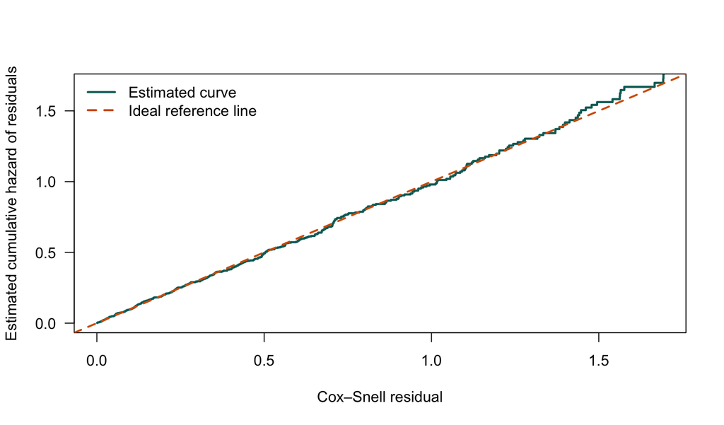

Cox–Snell residual diagnostic for the Weibull AFT model. An estimated cumulative hazard close to the 45-degree line is consistent with adequate overall distributional fit; late deviations are often affected by dwindling risk sets.

```r
aft_linear_predictor <- predict(aft_weibull, type = "lp")
cox_snell_residual <- exp(
  (log(survival_data$time_months) - aft_linear_predictor) /
    aft_weibull$scale
)

cox_snell_fit <- survival::survfit(
  survival::Surv(cox_snell_residual, survival_data$event) ~ 1
)
cox_snell_cumhaz <- -log(cox_snell_fit$surv)
diagnostic_limit <- unname(
  quantile(cox_snell_fit$time, probs = 0.95)
)

plot(
  cox_snell_fit$time,
  cox_snell_cumhaz,
  type = "s",
  lwd = 2.3,
  col = palette_surv["teal"],
  xlim = c(0, diagnostic_limit),
  ylim = c(0, diagnostic_limit),
  xlab = "Cox–Snell residual",
  ylab = "Estimated cumulative hazard of residuals",
  las = 1
)
abline(
  a = 0,
  b = 1,
  lty = 2,
  lwd = 2,
  col = palette_surv["vermillion"]
)
legend(
  "topleft",
  legend = c("Estimated curve", "Ideal reference line"),
  col = c(palette_surv["teal"], palette_surv["vermillion"]),
  lty = c(1, 2),
  lwd = 2.2,
  bty = "n"
)
```

A Cox–Snell plot is a global check and may conceal a misspecified functional form for one covariate. Also compare observed and predicted survival within groups, inspect deviance or response residuals, assess continuous-variable forms, and internally validate key predictions. A deviation caused by a few observations in the tail should not be interpreted in the same way as systematic deviation across the main follow-up range.

## 3.7 What assumptions does an AFT model require?

- **Correct distributional form:** the selected Weibull, log-normal, or other distribution must reasonably describe conditional event times;
- **Constant acceleration factor:** a covariate stretches or compresses the entire conditional time distribution by the same factor;
- **Correct covariate functional form:** the form of a continuous variable on the log-time scale must be reasonable;
- **Conditional independent censoring:** after conditioning on model information, censoring carries no further information about the potential event time;
- **Correct observation structure:** clustering, recurrent events, competing risks, and delayed entry require suitable methods;
- **Defensible extrapolation:** predictions beyond observed follow-up are driven primarily by assumptions about the distributional tail.

Statistical significance cannot choose the effect scale Do not report an HR merely because the Cox p-value is smaller, and do not ignore distributional fit merely because an AFT TR is more intuitive. The research question, target estimand, and assumptions should determine the primary model before the results are known.

**Check your understanding: what does TR = 1.25 mean?**

How should a TR of 1.25 for a binary exposure be interpreted in a standard AFT model?

**Answer:** Holding other covariates fixed and assuming the AFT model holds, every quantile of the exposed group’s conditional event-time distribution is 1.25 times the corresponding reference-group quantile, so the time scale is extended by approximately 25%. This is not an HR of 0.75 and does not directly mean a 25% reduction in risk at a fixed time.

# 4 Relationships, Differences, and Choice Between AFT and Cox PH Models

## 4.1 The two models do not negate each other

| Feature | Cox PH | Parametric AFT |
| --- | --- | --- |
| Principal question | How much does the instantaneous event rate change relatively? | How much is event time stretched or compressed? |
| Principal effect measure | HR $=\exp(\beta_{\text{PH}})$ | TR $=\exp(\beta_{\text{AFT}})$ |
| Baseline structure | No parametric shape specified for $h_0(t)$ | A complete time distribution must be selected |
| Likelihood information | Partial likelihood estimates relative-hazard coefficients | Full likelihood estimates location and scale jointly |
| Core effect assumption | The HR remains constant over time | The time distribution is scaled by a constant factor |
| Absolute prediction | Estimated baseline survival supports prediction within the observed range | Quantiles and survival probabilities can be predicted directly |
| Extrapolation | Generally unsuitable beyond the last event time | Computable, but highly dependent on the tail distribution |
| Interpretive advantage | Common in clinical literature; flexible baseline hazard | “How much earlier or later?” is often easier to communicate |

Cox PH and AFT models do not reduce to a simple contrast in which semiparametric models are always robust and parametric models are always risky. A Cox model still requires proportional hazards, functional forms, and the censoring structure to be appropriate. When its distribution is reasonable, an AFT model can be efficient and provide a direct time-scale interpretation.

## 4.2 Weibull is the intersection of the two model families

The Weibull distribution belongs to both the PH and AFT families. Let the AFT `survreg` scale be $\sigma$ and the Weibull shape be $\kappa=1/\sigma$. For the same covariate, the coefficients then satisfy:

$\beta_{\text{PH}}=-\kappa\beta_{\text{AFT}}$

$HR=\exp(-\kappa\beta_{\text{AFT}})=TR^{-\kappa}$

```r
aft_implied_hr <- exp(
  -aft_weibull_shape * aft_treatment_beta
)

bridge_table <- data.frame(
  Source = c("Direct Cox PH estimate", "Converted from Weibull AFT"),
  Intervention_vs_standard_HR = c(
    cox_treatment_hr,
    aft_implied_hr
  )
)

knitr::kable(
  bridge_table,
  digits = 3,
  col.names = c("Source", "HR: intervention vs standard management"),
  caption = "Comparison of HRs when a Weibull model satisfies both PH and AFT"
)
```

Comparison of HRs when a Weibull model satisfies both PH and AFT

| Source | HR: intervention vs standard management |
| --- | --- |
| Direct Cox PH estimate | 0.669 |
| Converted from Weibull AFT | 0.669 |

The two estimates are close in this example because the data were simulated from a Weibull mechanism; this should not be expected for every dataset. Log-normal and log-logistic AFT models generally do not produce a constant HR and cannot use this conversion. Even when the same data approximately satisfy both structures, HRs and TRs still answer different questions.

## 4.3 A practical selection process

1. **Write down the target estimand first.** Does the decision-maker need risk at a fixed time, an HR, a TR, median event time, or an RMST difference?
2. **Plot KM curves and numbers at risk.** Examine curve shapes, crossings, censoring, and the time range supported by the data.
3. **Specify the primary model from the question.** Do not choose an interpretation scale after inspecting p-values.
4. **Assess core assumptions.** Assess PH for Cox; assess time scaling and distributional calibration for AFT; assess functional forms and censoring for both.
5. **Report absolute quantities.** Even when the primary effect is an HR or TR, give a survival probability at a prespecified time or an event-time quantile.
6. **Perform sensitivity analyses.** Compare reasonable distributions, time-varying effects, nonlinear forms, and potentially informative censoring.
7. **Limit extrapolation and causal language.** Model fit does not automatically make the study design support causal interpretation.

### 4.3.1 When Cox PH may be preferable

- the research question and field conventions explicitly focus on conditional instantaneous event rates;
- no parametric distribution is desired for the baseline hazard;
- the primary focus is a relative effect during observed follow-up;
- proportional hazards is approximately reasonable over the important time range.

### 4.3.2 When AFT may be preferable

- “How much is the event delayed or advanced?” is the primary scientific question;
- a reasonable distribution agrees with the mechanism, plots, and diagnostics;
- conditional event-time quantiles or well-validated parametric predictions are needed;
- PH is inappropriate and constant time scaling is better supported.

### 4.3.3 When neither may be the best primary choice

- curves cross clearly and the effect direction changes over time;
- competing events are common and the target is cumulative incidence;
- recurrent events, multistate transitions, or complex clustering are present;
- the primary target is average event-free time within a fixed window, for which RMST may be more direct;
- censoring depends strongly on unobserved health status, making a simple independent-censoring model indefensible.

**Check your understanding: can Cox AIC and Weibull AFT AIC be compared?**

Both models were fitted to the same data. Can the model with the smaller AIC be selected?

**Answer:** Not directly. Standard Cox coefficients come from a partial likelihood, whereas a parametric AFT model’s AIC comes from a full event-time likelihood; their likelihood bases differ. AIC can be compared across full-likelihood parametric models fitted to the same data and outcome, but diagnostics and the research question still matter.

# 5 Common Complexities and Pitfalls

## 5.1 Delayed entry, clustering, and recurrent events

- **Delayed entry:** in a Cox model, a participant contributes to the risk set only after entering the study; use `coxph(Surv(entry, exit, event) ~ ...)`. Ignoring entry conditions can cause selection bias. Standard `survreg()` does not support this start–stop input, so a parametric AFT analysis with left truncation requires another implementation with the appropriate likelihood;
- **center or household clustering:** depending on the target, use cluster-robust standard errors, a shared frailty, or a multilevel model;
- **recurrent events:** when the same person can experience the outcome multiple times, event gaps, the overall event process, and terminal events require explicit definitions;
- **multistate processes:** transitions such as “healthy → hospitalized → dead” cannot be represented fully by a single endpoint.

Changing only the standard errors cannot repair an incorrect risk set, time origin, or target estimand.

## 5.2 Competing risks

If death prevents recurrence, death is a competing event for recurrence. When a competing death is treated as ordinary censoring:

- a cause-specific Cox model can estimate the cause-specific hazard;
- however, $1-\widehat S(t)$ is generally not the cumulative incidence of the event of interest;
- if the target is real-world cumulative incidence, use a cumulative incidence function and specify whether the effect scale is cause-specific or subdistribution-based.

Treating a competing event as censoring is not a computational error, but it changes the estimand and must align with the research question.

## 5.3 Missing data and measurement time

A complete-case analysis can be unbiased only under missingness conditions appropriate to the target analysis. A multiple-imputation model should include outcome information, follow-up information, important auxiliary variables, and variables related to missingness. Treating a covariate measured after the event as a baseline adjustment variable can control a mediator, introduce collider bias, or violate temporal order.

## 5.4 Causal interpretation requires additional conditions

An adjusted HR or TR may still be affected by unmeasured confounding, selection bias, measurement error, and model specification. If the target is a causal effect, specify:

- the intervention, comparator, and target population;
- the start of follow-up, grace period, and treatment strategy;
- baseline confounders and their causal justification;
- handling of loss to follow-up and treatment switching;
- whether the target effect is conditional or marginal;
- identification conditions such as consistency, exchangeability, and positivity.

Adjustment variables should be selected from the research question, temporal order, and causal structure, not screened by univariable p-values. Continuous variables should not be dichotomized arbitrarily merely to create “significant groups.”

Model accuracy is not decision fairness High-risk predictions may reflect access to care, opportunities for diagnosis, or structural inequities rather than biological risk alone. When reporting a model, examine variable meanings, censoring and calibration across groups, potential harms, and how results will be used.

# 6 Guided Mini Case Study

## 6.1 Research question and analysis plan

**Research question:** In the simulated cohort, how is the intervention associated with time to the first occurrence of the study endpoint?

Before examining the results, prespecify:

- primary Cox estimand: the intervention HR adjusted for age, severity, and biomarker level;
- primary AFT estimand: the Weibull TR with the same adjustment variables;
- absolute outcome: the 12-month probability of remaining event-free for a 55-year-old reference individual with mild severity and a biomarker value of 0;
- diagnostics: PH assessment, AFT distribution comparison, and a Cox–Snell plot;
- interpretive limits: intervention is not randomized and all data are simulated.

## 6.2 Step 1: Bring descriptive, relative, and absolute results together

```r
km_median <- summary(km_fit)$table

case_relative <- data.frame(
  Model = c("Cox PH", "Weibull AFT"),
  Effect_measure = c("HR", "TR"),
  Estimate = c(cox_treatment_hr, aft_treatment_tr),
  `95% CI lower` = c(cox_treatment_ci[1], aft_treatment_ci[1]),
  `95% CI upper` = c(cox_treatment_ci[2], aft_treatment_ci[2]),
  check.names = FALSE
)

case_medians <- data.frame(
  Management = c("Standard management", "Intervention"),
  `Unadjusted KM median time (months)` = km_median[, "median"],
  `95% CI lower` = km_median[, "0.95LCL"],
  `95% CI upper` = km_median[, "0.95UCL"],
  check.names = FALSE
)

knitr::kable(
  case_relative,
  digits = 3,
  col.names = c("Model", "Effect measure", "Estimate", "95% CI lower", "95% CI upper"),
  caption = "Two adjusted relative-effect scales"
)
```

Two adjusted relative-effect scales

| Model | Effect measure | Estimate | 95% CI lower | 95% CI upper |
| --- | --- | --- | --- | --- |
| Cox PH | HR | 0.669 | 0.549 | 0.815 |
| Weibull AFT | TR | 1.306 | 1.146 | 1.487 |

```r
knitr::kable(
  case_medians,
  digits = 2,
  col.names = c(
    "Management strategy", "Unadjusted KM median time (months)",
    "95% CI lower", "95% CI upper"
  ),
  caption = "Unadjusted KM median event time by management strategy"
)
```

Unadjusted KM median event time by management strategy

|  | Management strategy | Unadjusted KM median time (months) | 95% CI lower | 95% CI upper |
| --- | --- | --- | --- | --- |
| treatment=Standard | Standard management | 13.0 | 11.2 | 14.1 |
| treatment=Intervention | Intervention | 15.7 | 14.3 | 18.2 |

An unadjusted KM median and an adjusted AFT conditional median are not the same estimand. The former describes the observed covariate mixture within each group; the latter fixes or conditions on covariates in the model.

## 6.3 Step 2: Calculate absolute 12-month survival probabilities

```r
cox_12_summary <- summary(
  cox_reference_curves,
  times = 12
)
cox_survival_12 <- as.numeric(cox_12_summary$surv)
cox_survival_12_lower <- as.numeric(cox_12_summary$lower)
cox_survival_12_upper <- as.numeric(cox_12_summary$upper)

aft_reference_lp <- predict(
  aft_weibull,
  newdata = reference_profiles,
  type = "lp"
)
aft_survival_12 <- exp(
  -exp(
    (log(12) - aft_reference_lp) /
      aft_weibull$scale
  )
)

# Use simulation to propagate the large-sample joint covariance of survreg parameters.
set.seed(20260814)
n_parameter_draws <- 4000
aft_parameter_mean <- c(
  coef(aft_weibull),
  log(aft_weibull$scale)
)
standard_normal_draws <- matrix(
  rnorm(n_parameter_draws * length(aft_parameter_mean)),
  nrow = n_parameter_draws
)
aft_parameter_draws <- sweep(
  standard_normal_draws %*% chol(aft_weibull$var),
  MARGIN = 2,
  STATS = aft_parameter_mean,
  FUN = "+"
)

n_aft_coefficients <- length(coef(aft_weibull))
aft_beta_draws <- aft_parameter_draws[
  , seq_len(n_aft_coefficients), drop = FALSE
]
aft_sigma_draws <- exp(
  aft_parameter_draws[, n_aft_coefficients + 1]
)
aft_reference_matrix <- model.matrix(
  delete.response(terms(aft_weibull)),
  data = reference_profiles
)
aft_lp_draws <- aft_beta_draws %*% t(aft_reference_matrix)
aft_standardized_time <- sweep(
  log(12) - aft_lp_draws,
  MARGIN = 1,
  STATS = aft_sigma_draws,
  FUN = "/"
)
aft_survival_draws <- exp(-exp(aft_standardized_time))
aft_survival_12_ci <- apply(
  aft_survival_draws,
  MARGIN = 2,
  FUN = quantile,
  probs = c(0.025, 0.975)
)

all_survival_12 <- c(cox_survival_12, aft_survival_12)
all_survival_12_lower <- c(
  cox_survival_12_lower,
  aft_survival_12_ci[1, ]
)
all_survival_12_upper <- c(
  cox_survival_12_upper,
  aft_survival_12_ci[2, ]
)

absolute_results <- data.frame(
  Model = rep(c("Cox PH", "Weibull AFT"), each = 2),
  Management = rep(c("Standard management", "Intervention"), times = 2),
  `12-month survival probability` = all_survival_12,
  `95% CI lower` = all_survival_12_lower,
  `95% CI upper` = all_survival_12_upper,
  `12-month cumulative event probability` = 1 - all_survival_12,
  check.names = FALSE
)

knitr::kable(
  absolute_results,
  digits = 3,
  col.names = c(
    "Model", "Management strategy", "12-month survival probability",
    "95% CI lower", "95% CI upper", "12-month cumulative event probability"
  ),
  caption = "Conditional 12-month model predictions and 95% confidence intervals for the reference profile"
)
```

Conditional 12-month model predictions and 95% confidence intervals for the reference profile

| Model | Management strategy | 12-month survival probability | 95% CI lower | 95% CI upper | 12-month cumulative event probability |
| --- | --- | --- | --- | --- | --- |
| Cox PH | Standard management | 0.611 | 0.557 | 0.670 | 0.389 |
| Cox PH | Intervention | 0.719 | 0.671 | 0.771 | 0.281 |
| Weibull AFT | Standard management | 0.605 | 0.552 | 0.657 | 0.395 |
| Weibull AFT | Intervention | 0.715 | 0.666 | 0.759 | 0.285 |

For this reference individual, the Cox model estimates that 12-month survival probability increases from 61.1% under standard management to 71.9% under intervention. This is a conditional model prediction, not a marginal risk from a randomized trial, and it does not imply that every participant would receive the same benefit.

The Cox intervals reflect asymptotic model uncertainty. The AFT intervals propagate the joint covariance of coefficients and log scale through 4,000 draws from a normal parameter approximation. Both condition on the selected model form and omit uncertainty from distribution selection, unmeasured confounding, and prediction error in new data.

## 6.4 Step 3: Compare model predictions within the observed range

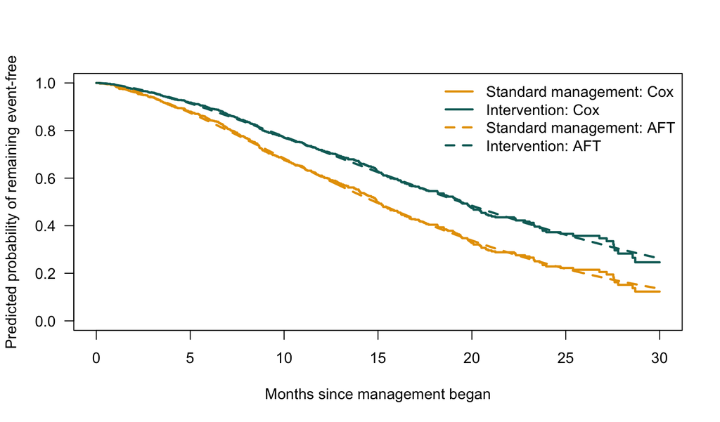

Survival predictions from Cox PH and Weibull AFT models for the same reference individual. Color identifies management strategy and line type identifies model; agreement over the observed range does not guarantee agreement in long-term extrapolation.

```r
prediction_times <- seq(0.1, 30, by = 0.1)
aft_curve_matrix <- sapply(
  aft_reference_lp,
  function(mu) {
    exp(
      -exp(
        (log(prediction_times) - mu) /
          aft_weibull$scale
      )
    )
  }
)

plot(
  cox_reference_curves,
  col = c(palette_surv["orange"], palette_surv["teal"]),
  lwd = 2.4,
  lty = 1,
  conf.int = FALSE,
  xlab = "Months since management began",
  ylab = "Predicted probability of remaining event-free",
  xlim = c(0, 30),
  ylim = c(0, 1),
  las = 1
)
lines(
  prediction_times,
  aft_curve_matrix[, 1],
  col = palette_surv["orange"],
  lwd = 2.4,
  lty = 2
)
lines(
  prediction_times,
  aft_curve_matrix[, 2],
  col = palette_surv["teal"],
  lwd = 2.4,
  lty = 2
)
legend(
  "topright",
  legend = c(
    "Standard management: Cox", "Intervention: Cox",
    "Standard management: AFT", "Intervention: AFT"
  ),
  col = c(
    palette_surv["orange"], palette_surv["teal"],
    palette_surv["orange"], palette_surv["teal"]
  ),
  lty = c(1, 1, 2, 2),
  lwd = 2.3,
  bty = "n"
)
```

The two predictions are close in this example, as expected under the Weibull data-generating mechanism. In a real study, compare calibration only where enough participants remain at risk. Do not allow curves to extend automatically into poorly supported long-term follow-up and then interpret them with certainty.

## 6.5 Step 4: Write an auditable result

Among 650 simulated participants, 416 first endpoints were observed and 234 participants were right-censored. After adjustment for age, baseline severity, and biomarker level, intervention was associated with a lower conditional instantaneous event rate (Cox HR = 0.67, 95% CI 0.55–0.82). The Weibull AFT model estimated that conditional event times were multiplied by 1.31 (95% CI 1.15–1.49). PH residuals showed no clear global departure, Weibull had the lowest AIC among candidate parametric distributions, and the Cox–Snell curve remained close to the reference line over the main range. Because management strategy was not randomized and neither independent censoring nor model form can be verified completely, these associations should not be interpreted as real-world causal treatment effects.

### 6.5.1 Reporting template

> In **[target population]**, participants were followed from **[time zero]** to **[explicit event]** for **[duration]**. After adjustment for **[prespecified covariates]**, the **[HR/TR]** for **[exposure]** versus **[comparator]** was **[estimate]** (95% CI: **[lower, upper]**). At **[prespecified time or covariate profile]**, the model-estimated survival probabilities were **[values]**. Diagnostics for **[PH/AFT distribution/censoring/functional form]** showed **[findings]**. Because of **[specific design or data limitation]**, the result should be interpreted as **[an association/a conditional prediction/a causal effect under additional conditions]**.

**Mini-case reflection: why report absolute survival probabilities as well?**

If both the HR and TR have confidence intervals, why also provide 12-month survival probabilities?

**Answer:** A relative effect does not reveal the baseline event level. The same HR can correspond to very different absolute benefits in low- and high-risk populations, and a TR does not directly provide event probability at a fixed time. Absolute outcomes align more closely with many decisions, but the corresponding population, covariate profile, and time point must be stated.

# 7 Common Errors at a Glance

| Common statement or practice | Problem | Better approach |
| --- | --- | --- |
| Treating `event=0` as the event | Reverses the directions of event and censoring | Verify explicitly that `1 = event` and `0 = censored`, and inspect raw counts |
| “HR 0.70 means a 30% lower one-year risk” | Treats an instantaneous rate ratio as a cumulative risk ratio | Name the HR correctly and report one-year survival probability or risk separately |
| Treating `exp(survreg coefficient)` as an HR | An exponentiated AFT coefficient is a TR | Interpret it on the time scale; convert only under a compatible Weibull model |
| Treating `survreg$scale` as the Weibull shape | R uses the reciprocal parameterization | Use `shape = 1 / fit$scale` |
| Declaring PH valid because `cox.zph` p > 0.05 | Failure to reject is not proof | Combine residual plots, power, numbers at risk, and subject-matter knowledge |
| Automatically switching to AFT when PH fails | Failure of PH does not guarantee constant time scaling | Assess the AFT distribution and acceleration-factor assumption independently |
| Comparing Cox and AFT AIC values | Partial- and full-likelihood bases differ | Compare only candidate parametric models that share the same full-likelihood basis |
| Assuming robust standard errors repair the model | A variance correction cannot fix non-PH, nonlinearity, or an incorrect risk set | Correct the model structure and perform targeted sensitivity analyses |
| Predicting beyond the last observed time without disclosure | Results are driven mainly by tail-distribution assumptions | Mark the observed range clearly and compare extrapolations across reasonable distributions |
| Reporting only an HR or TR | Omits the baseline level and decision-relevant absolute quantities | Also report survival probability, risk, or a time quantile at a prespecified time |

# 8 Quick Reference

## 8.1 Core formulas

| Concept | Formula | Principal interpretation |
| --- | --- | --- |
| Survival function | $S(t)=P(T>t)$ | Probability of remaining event-free through $t$ |
| Cumulative hazard | $H(t)=-\log S(t)$ | Accumulation of instantaneous hazard over time |
| Cox PH | $h(t\mid X)=h_0(t)e^{X\beta}$ | $e^{\beta}$ is a conditional HR |
| AFT | $\log T=X\beta+\sigma\varepsilon$ | $e^{\beta}$ is a conditional TR |
| Weibull parameter bridge | $\kappa=1/\sigma$ | The reciprocal of `survreg` scale is shape |
| Weibull conversion | $HR=TR^{-\kappa}$ | Valid only for compatible Weibull PH/AFT models |
| Cumulative event probability at a fixed time | $F(t)=1-S(t)$ | Probability of an event by $t$ in the absence of competing risks |

## 8.2 Common R code

| Goal | Code pattern |
| --- | --- |
| Construct a right-censored outcome | `survival::Surv(time, event)` |
| Kaplan–Meier curve | `survival::survfit(survival::Surv(time, event) ~ group, data = d)` |
| Cox PH | `survival::coxph(survival::Surv(time, event) ~ x1 + x2, data = d)` |
| PH diagnostic | `survival::cox.zph(cox_fit)` |
| Adjusted Cox curve | `survival::survfit(cox_fit, newdata = profiles)` |
| Weibull AFT | `survival::survreg(survival::Surv(time, event) ~ x1 + x2, data = d, dist = "weibull")` |
| AFT time ratios | `exp(coef(aft_fit)[names(coef(aft_fit)) != "(Intercept)"])` |
| AFT conditional quantile | `predict(aft_fit, newdata = profiles, type = "quantile", p = 0.5)` |
| Candidate parametric-model AIC | `AIC(aft_weibull, aft_lognormal)` |

## 8.3 Pre-modeling checklist

- Are the time origin, event, time scale, and observation endpoint explicit?
- Is the event truly coded `1` and censoring coded `0`?
- Are delayed entry, competing events, recurrent events, or clustering present?
- What are the event count, censoring proportion, and number at risk in each group?
- Is the primary target an HR, TR, fixed-time risk, quantile, or RMST?
- Were the units, centering, and functional forms of continuous variables prespecified?
- Were unsupported arbitrary cutpoints for continuous variables avoided?
- Were adjustment variables measured before time zero, and do they have a defensible causal basis?
- Are there enough events to support the fitted parameters and interactions?

## 8.4 Post-fit diagnostic checklist

### 8.4.1 Cox PH

- examine KM curves, log-minus-log plots, and numbers at risk;
- examine global and covariate-specific `cox.zph()` results and residual plots;
- assess continuous-variable nonlinearity, unusual observations, and dfbeta influence;
- evaluate clustering, tied events, and the censoring mechanism;
- assess absolute predictions and calibration at prespecified times.

### 8.4.2 AFT

- compare scientifically reasonable candidate distributions rather than searching every available distribution;
- assess Cox–Snell residuals and agreement between observed and predicted survival within groups;
- assess continuous-variable functional forms on the log-time scale;
- evaluate sensitivity of key conclusions to the distributional tail and censoring assumptions;
- state the `survreg` distribution, scale, and software parameterization explicitly;
- separate extrapolated results clearly from the actual observed range.

## 8.5 Plain-language glossary

| Term | Meaning |
| --- | --- |
| Risk set | People still observed and event-free immediately before an event time |
| Right censoring | Knowing only that event time is later than the last observation |
| Delayed entry | A participant begins contributing to the risk set after time zero |
| Survival probability | Probability of remaining free of the target event through a specified time |
| Hazard function | Instantaneous event rate immediately afterward among people still event-free |
| HR | Ratio of two conditional instantaneous event rates |
| TR | Multiplier for conditional event-time quantiles in an AFT model |
| Proportional hazards | An HR that remains constant over the analysis time range |
| Acceleration factor | Multiplier that stretches or compresses the event-time scale in an AFT model |
| Baseline hazard | Hazard function in a Cox model when all covariates are at their reference values |
| Partial likelihood | Cox method that uses event ordering and risk sets to estimate relative-hazard coefficients |
| Extrapolation | Prediction beyond the time range actually supported by the data |

# 9 Final Knowledge Check

1. Does a right-censored participant still contribute information to the risk set before censoring?
2. Does HR = 0.60 necessarily imply a 12-month risk ratio of 0.60?
3. Why does Cox PH not require choosing a Weibull or log-normal distribution for $h_0(t)$?
4. Does a global `cox.zph()` p-value of 0.40 prove that PH holds?
5. What does $\exp(\beta)=1.40$ mean in an AFT model?
6. If `survreg(dist="weibull")` reports scale = 0.80, what is the Weibull shape?
7. Can a TR from a log-normal AFT model usually be converted to a constant HR?
8. Why should AIC not be used to compare a standard Cox model directly with a parametric AFT model?
9. If a competing death is treated as ordinary censoring, is $1-\widehat S(t)$ still the cumulative incidence of recurrence?
10. Does a statistically significant multivariable-adjusted HR automatically have a causal interpretation?

**Show final answers**

1. Yes. Information that the participant remained event-free before the censoring time contributes to the corresponding risk sets.
2. No. An HR is a conditional instantaneous rate ratio, whereas a fixed-time risk ratio compares cumulative probabilities.
3. Cox partial likelihood estimates $\beta$ through risk-set comparisons at event times without parameterizing the shape of the baseline hazard.
4. No. It means only that the current data provide no strong evidence against PH; power, plots, and subject-matter knowledge still matter.
5. Holding other covariates fixed and assuming the AFT model holds, every conditional event-time quantile is multiplied by 1.40, extending the time scale by approximately 40%.
6. Shape = $1/0.80=1.25$.
7. Usually not. A log-normal AFT model generally does not satisfy constant proportional hazards.
8. Cox uses a partial likelihood, while a parametric AFT model uses a full event-time likelihood, so their AIC values have different likelihood bases.
9. Usually not. A cumulative incidence function is needed to express real-world cumulative probability in the presence of competing risks.
10. No. Appropriate study design, temporal ordering, control of confounding, measurement, censoring, and identification assumptions are still required.

## Next steps

Further topics include restricted mean survival time, flexible parametric survival models, splines and time-varying effects, time-varying covariates, competing risks, multistate models, recurrent events, frailty, causal survival analysis, weighting methods for informative censoring, multiple imputation, and internal and external validation.

**Teaching use:** This module supports learning about estimation, diagnosis, and interpretation of survival models. It does not replace a statistical analysis plan, data audit, or professional biostatistical consultation for a specific study. All data and numerical results are simulated.